# Excel napredno 1. del

Teodor Petrič

2021-5-21

# 0. Programi

```r
library(tidyverse)
library(scales)
library(tidymodels)
library(tidytext)
library(readxl)
```

# 1. Podatki

Podatki in posamezne naloge za delo z Excelom so iz seminarja dr. Simone Sternad Zabukovšek in mag. Zdenka Deželaka (Univerza v Mariboru, 21.5.2021).

Primerjamo z Excelom.

R: Oba delovna lista iz datoteke “Narocila.xlsx”) shranjujemo kot samostojni tabeli z imenoma “orders” in “zaposleni”.

```r
orders = read_xlsx("data/Narocilo.xlsx", sheet = "Orders")
zaposleni = read_xlsx("data/Narocilo.xlsx", sheet = "Zaposleni")
```

Poglejmo prve podatke:

```r
head(orders)
```

```
## # A tibble: 6 x 4
##   OrderID CustomerID EmployeeID OrderDate
##     <dbl> <chr>           <dbl> <dttm>
## 1   10248 VINET               5 1994-08-04 00:00:00
## 2   10249 TOMSP               6 1994-08-05 00:00:00
## 3   10250 HANAR               4 1994-08-08 00:00:00
## 4   10251 VICTE               3 1994-08-08 00:00:00
## 5   10252 SUPRD               4 1994-08-09 00:00:00
## 6   10253 HANAR               3 1994-08-10 00:00:00
```

```r
head(zaposleni)
```

```
## # A tibble: 6 x 13
##   EmployeeID LastName  FirstName Title       TitleOfCourtesy BirthDate
##        <dbl> <chr>     <chr>     <chr>       <chr>           <dttm>
## 1          1 Davolio   Nancy     Sales Repr~ Ms.             1948-12-08 00:00:00
## 2          2 Fuller    Andrew    Vice Presi~ Dr.             1952-02-19 00:00:00
## 3          3 Leverling Janet     Sales Repr~ Ms.             1963-08-30 00:00:00
## 4          4 Peacock   Margaret  Sales Repr~ Mrs.            1937-09-19 00:00:00
## 5          5 Buchanan  Steven    Sales Mana~ Mr.             1955-03-04 00:00:00
## 6          6 Suyama    Michael   Sales Repr~ Mr.             1963-07-02 00:00:00
## # ... with 7 more variables: HireDate <dttm>, Address <chr>, City <chr>,
## #   Region <chr>, PostalCode <chr>, Country <chr>, HomePhone <chr>
```

# 2. Število podatkov v nizu

R: Načinov je več.

```r
nrow(orders) # vrstice
```

```
## [1] 830
```

```r
ncol(orders) # stolpci
```

```
## [1] 4
```

```r
dim(orders) # vrstice x stolpci (dimenzije)
```

```
## [1] 830   4
```

# 3. Lookup (Excel)

Excel (lookup): Na delovnem listu Zaposleni dodajte: - V celico P1 napišite besedilo »Vpišite številko ID«, v celici P2 vpišite besedilo »Telefonska številka«, v celico P3 pa »Datum zaposlitve«. - Nastavite, da se bo na podlagi vpisane ID številke v celici Q1, v celico Q2 izpisala telefonska številka (namig: Lookup). - Nastavite, da se bo na podlagi vpisane ID številke v celici Q1, v celico Q3 izpisal datum zaposlitve (namig: Lookup).

R:

```r
zaposleni %>%
  select(EmployeeID, HomePhone, HireDate) %>%
  filter(EmployeeID == 1)
```

```
## # A tibble: 1 x 3
##   EmployeeID HomePhone      HireDate
##        <dbl> <chr>          <dttm>
## 1          1 (206) 555-9857 1992-05-01 00:00:00
```

# 4. Vlookup, &, Concat

Excel: Na delovnem listu Orders dodajte: o Stolpec Priimek, v katerem naj bo izpisan Priimek zaposlenega glede na ID zaposlenega (namig: Vlookup). o Stolpec Ime, katerem naj bo izpisan Ime zaposlenega glede na ID zaposlenega o Stolpec Ime in priimek (združite predhodna dva). Preverite različne možnosti: • Bliskovita zapolnitev. • Formula (=Stolpec1&" "&Stolpec2). • Funkcija (CONCAT).

R: Podatkovna niza “orders” in “zaposleni” imata skupen stolpec “EmployeeID”. Ta bo osnova za združevanje obeh podatkovnih nizov. Nadaljnje iskanje ali filtriranje bo tako enostavno.

```r
(zdruzena = orders %>%
  left_join(zaposleni, by = "EmployeeID", keep = FALSE)
)
```

```
## # A tibble: 830 x 16
##    OrderID CustomerID EmployeeID OrderDate           LastName  FirstName Title
##      <dbl> <chr>           <dbl> <dttm>              <chr>     <chr>     <chr>
##  1   10248 VINET               5 1994-08-04 00:00:00 Buchanan  Steven    Sales ~
##  2   10249 TOMSP               6 1994-08-05 00:00:00 Suyama    Michael   Sales ~
##  3   10250 HANAR               4 1994-08-08 00:00:00 Peacock   Margaret  Sales ~
##  4   10251 VICTE               3 1994-08-08 00:00:00 Leverling Janet     Sales ~
##  5   10252 SUPRD               4 1994-08-09 00:00:00 Peacock   Margaret  Sales ~
##  6   10253 HANAR               3 1994-08-10 00:00:00 Leverling Janet     Sales ~
##  7   10254 CHOPS               5 1994-08-11 00:00:00 Buchanan  Steven    Sales ~
##  8   10255 RICSU               9 1994-08-12 00:00:00 Dodsworth Anne      Sales ~
##  9   10256 WELLI               3 1994-08-15 00:00:00 Leverling Janet     Sales ~
## 10   10257 HILAA               4 1994-08-16 00:00:00 Peacock   Margaret  Sales ~
## # ... with 820 more rows, and 9 more variables: TitleOfCourtesy <chr>,
## #   BirthDate <dttm>, HireDate <dttm>, Address <chr>, City <chr>, Region <chr>,
## #   PostalCode <chr>, Country <chr>, HomePhone <chr>
```

Novo obliko tabele (gl. spodaj) bi lahko shranil pod novim imenom (npr. “zdruzena_nova”). Prvotna tabela “zdruzena” ostane, kot jo vidite zgoraj.

```r
zdruzena %>%
  unite(EmployeeName, LastName:FirstName, sep = " ")
```

```
## # A tibble: 830 x 15
##    OrderID CustomerID EmployeeID OrderDate           EmployeeName   Title
##      <dbl> <chr>           <dbl> <dttm>              <chr>          <chr>
##  1   10248 VINET               5 1994-08-04 00:00:00 Buchanan Stev~ Sales Manag~
##  2   10249 TOMSP               6 1994-08-05 00:00:00 Suyama Michael Sales Repre~
##  3   10250 HANAR               4 1994-08-08 00:00:00 Peacock Marga~ Sales Repre~
##  4   10251 VICTE               3 1994-08-08 00:00:00 Leverling Jan~ Sales Repre~
##  5   10252 SUPRD               4 1994-08-09 00:00:00 Peacock Marga~ Sales Repre~
##  6   10253 HANAR               3 1994-08-10 00:00:00 Leverling Jan~ Sales Repre~
##  7   10254 CHOPS               5 1994-08-11 00:00:00 Buchanan Stev~ Sales Manag~
##  8   10255 RICSU               9 1994-08-12 00:00:00 Dodsworth Anne Sales Repre~
##  9   10256 WELLI               3 1994-08-15 00:00:00 Leverling Jan~ Sales Repre~
## 10   10257 HILAA               4 1994-08-16 00:00:00 Peacock Marga~ Sales Repre~
## # ... with 820 more rows, and 9 more variables: TitleOfCourtesy <chr>,
## #   BirthDate <dttm>, HireDate <dttm>, Address <chr>, City <chr>, Region <chr>,
## #   PostalCode <chr>, Country <chr>, HomePhone <chr>
```

```r
(zdruzena_nova = zdruzena %>%
  unite(EmployeeName, c(FirstName, LastName), sep = " ")
)
```

```
## # A tibble: 830 x 15
##    OrderID CustomerID EmployeeID OrderDate           EmployeeName   Title
##      <dbl> <chr>           <dbl> <dttm>              <chr>          <chr>
##  1   10248 VINET               5 1994-08-04 00:00:00 Steven Buchan~ Sales Manag~
##  2   10249 TOMSP               6 1994-08-05 00:00:00 Michael Suyama Sales Repre~
##  3   10250 HANAR               4 1994-08-08 00:00:00 Margaret Peac~ Sales Repre~
##  4   10251 VICTE               3 1994-08-08 00:00:00 Janet Leverli~ Sales Repre~
##  5   10252 SUPRD               4 1994-08-09 00:00:00 Margaret Peac~ Sales Repre~
##  6   10253 HANAR               3 1994-08-10 00:00:00 Janet Leverli~ Sales Repre~
##  7   10254 CHOPS               5 1994-08-11 00:00:00 Steven Buchan~ Sales Manag~
##  8   10255 RICSU               9 1994-08-12 00:00:00 Anne Dodsworth Sales Repre~
##  9   10256 WELLI               3 1994-08-15 00:00:00 Janet Leverli~ Sales Repre~
## 10   10257 HILAA               4 1994-08-16 00:00:00 Margaret Peac~ Sales Repre~
## # ... with 820 more rows, and 9 more variables: TitleOfCourtesy <chr>,
## #   BirthDate <dttm>, HireDate <dttm>, Address <chr>, City <chr>, Region <chr>,
## #   PostalCode <chr>, Country <chr>, HomePhone <chr>
```

# 5. Transpose

Excel: Na nov delovni list kopirajte območje A1:M10 iz delovnega lista Zaposleni tako, da zamenjate vrstice s stolpci. o Izbrišite prvo vrstico. o Preimenujte delovni list v Vir.

R: Transponiranje tabele ni potrebno, ker smo prej že ustvarili združen podatkovni niz. Funkcija “t()” (tj. transpose) sicer deluje podobno kot v Excelu.

```r
vir = as.data.frame(t(zaposleni))

(vir = vir[-1,] %>% # izbrišemo prvo vrstico
  rownames_to_column(var = "Lastnosti") # nov stolpec
)
```

```
##          Lastnosti                              V1                    V2
## 1         LastName                         Davolio                Fuller
## 2        FirstName                           Nancy                Andrew
## 3            Title            Sales Representative Vice President, Sales
## 4  TitleOfCourtesy                             Ms.                   Dr.
## 5        BirthDate                      1948-12-08            1952-02-19
## 6         HireDate                      1992-05-01            1992-08-14
## 7          Address 507 - 20th Ave. E.\r\r\nApt. 2A    908 W. Capital Way
## 8             City                         Seattle                Tacoma
## 9           Region                              WA                    WA
## 10      PostalCode                           98122                 98401
## 11         Country                             USA                   USA
## 12       HomePhone                  (206) 555-9857        (206) 555-9482
##                      V3                   V4              V5
## 1             Leverling              Peacock        Buchanan
```

[output cut: 37 more lines]

# 6. Dvojniki, razdružitev

Excel: Z delovnega lista Orders kopirajte na nov delovni list stolpec Ime in Priimek (kot vrednosti). o Preimenujte delovni list v Kontakt. o Odstranite dvojnike iz celotnega stolpca. o Razdružite ime in priimek v ločena stolpca. o V naslednji stolpec v prvo celico napišite Rojstni datum in v stolpcu s pomočjo funkcije vstavite rojstne datume zaposlenih s tabele delovnega lista Vir (namig: Hlookup). Nastavite kratko obliko datuma. o V naslednji stolpec v prvo celico napišite Telefon in v stolpcu s pomočjo funkcije vstavite še telefonske številke zaposlenih.

R:

```r
(kontakt = zdruzena_nova %>%
  distinct(EmployeeName, .keep_all = T) %>%
  separate(EmployeeName, into = c("Ime", "Priimek")) %>%
  select(Ime, Priimek, Title, BirthDate, HomePhone)
)
```

```
## # A tibble: 9 x 5
##   Ime      Priimek   Title                    BirthDate           HomePhone
##   <chr>    <chr>     <chr>                    <dttm>              <chr>
## 1 Steven   Buchanan  Sales Manager            1955-03-04 00:00:00 (71) 555-4848
## 2 Michael  Suyama    Sales Representative     1963-07-02 00:00:00 (71) 555-7773
## 3 Margaret Peacock   Sales Representative     1937-09-19 00:00:00 (206) 555-8122
## 4 Janet    Leverling Sales Representative     1963-08-30 00:00:00 (206) 555-3412
## 5 Anne     Dodsworth Sales Representative     1966-01-27 00:00:00 (71) 555-4444
## 6 Nancy    Davolio   Sales Representative     1948-12-08 00:00:00 (206) 555-9857
## 7 Laura    Callahan  Inside Sales Coordinator 1958-01-09 00:00:00 (206) 555-1189
## 8 Andrew   Fuller    Vice President, Sales    1952-02-19 00:00:00 (206) 555-9482
## 9 Robert   King      Sales Representative     1960-05-29 00:00:00 (71) 555-5598
```

# 7. Xlookup

Excel: Postavite se na delovni list Zaposleni. o V celico S1 napišite besedilo »Vpišite ime«, v celici S2 vpišite besedilo »Telefonska številka«, v celico S3 pa »Naslov«. o Nastavite, da se bo na podlagi vpisanega imena v celici T1, v celico T2 izpisala telefonska številka (namig: Xlookup). o Nastavite, da se bo na podlagi vpisanega imena v celici T1, v celico T3 izpisal celotni naslov – Adress, City, Region, PostalCode, Country) (namig: Xlookup).

R:

```r
zdruzena_nova %>%
  filter(EmployeeName == "Steven Buchanan") %>%
  select(EmployeeName, HomePhone, Address:Country) %>%
  distinct() %>%
  unite(Naslov, Address:Country, sep = ", ") %>%
  rename(Telefon = HomePhone,
         Zaposleni = EmployeeName)
```

```
## # A tibble: 1 x 3
##   Zaposleni       Telefon       Naslov
##   <chr>           <chr>         <chr>
## 1 Steven Buchanan (71) 555-4848 14 Garrett Hill, London, NA, SW1 8JR, UK
```

# 8. Index, Match

Excel: Postavite se na delovni list Zaposleni v celico P6 in izpišite, kaj se vam nahaja v vrstici 5 in stolpcu 8 (namig: index). • V celico P7 izpišite številko vrstice, v kateri se nahaja priimek Fuller (namig: match). • Postavite se na delovni list Orders, v naslednji stolpec v prvo celico napišite Št. vrstice, ter na podlagi priimka poiščite v kateri vrstici se priimek nahaja v stolpcu Priimek v tabeli Zaposleni (namig: match). • Postavite se na delovni list Orders, v naslednji stolpec v prvo celico napišite Title, ter na podlagi stolpca Št. vrstice poiščite naziv zaposlenega iz tabele Zaposleni (stolpec Title; namig: index). • Postavite se na delovni list Orders, v naslednji stolpec v prvo celico napišite Title, ter na podlagi priimka s pomočjo funkcij Index in Match vstavite naziv zaposlenega s tabele delovnega lista Zaposleni. • V naslednji stolpec v prvo celico napišite Naslavljanje, ter na podlagi priimka s pomočjo funkcij Index in Match vstavite obliko naslavljanja zaposlenega s tabele delovnega lista Zaposleni.

```r
zaposleni[5,8] # vrstica 5, stolpec 8
```

```
## # A tibble: 1 x 1
##   Address
##   <chr>
## 1 14 Garrett Hill
```

```r
zaposleni %>%
  # add_rownames() %>% # opcionalen korak
  filter(str_detect(LastName, "Fuller")) %>%
  select(EmployeeID)
```

```
## # A tibble: 1 x 1
##   EmployeeID
##        <dbl>
## 1          2
```

```r
zdruzena_nova %>%
  filter(str_detect(EmployeeName, "Fuller"))
```

```
## # A tibble: 96 x 15
##    OrderID CustomerID EmployeeID OrderDate           EmployeeName  Title
##      <dbl> <chr>           <dbl> <dttm>              <chr>         <chr>
##  1   10265 BLONP               2 1994-08-25 00:00:00 Andrew Fuller Vice Preside~
##  2   10277 MORGK               2 1994-09-09 00:00:00 Andrew Fuller Vice Preside~
##  3   10280 BERGS               2 1994-09-14 00:00:00 Andrew Fuller Vice Preside~
##  4   10295 VINET               2 1994-10-03 00:00:00 Andrew Fuller Vice Preside~
##  5   10300 MAGAA               2 1994-10-10 00:00:00 Andrew Fuller Vice Preside~
##  6   10307 LONEP               2 1994-10-18 00:00:00 Andrew Fuller Vice Preside~
##  7   10312 WANDK               2 1994-10-24 00:00:00 Andrew Fuller Vice Preside~
##  8   10313 QUICK               2 1994-10-25 00:00:00 Andrew Fuller Vice Preside~
##  9   10327 FOLKO               2 1994-11-11 00:00:00 Andrew Fuller Vice Preside~
## 10   10339 MEREP               2 1994-11-28 00:00:00 Andrew Fuller Vice Preside~
## # ... with 86 more rows, and 9 more variables: TitleOfCourtesy <chr>,
## #   BirthDate <dttm>, HireDate <dttm>, Address <chr>, City <chr>, Region <chr>,
## #   PostalCode <chr>, Country <chr>, HomePhone <chr>
```

```r
kontakt %>%
  filter(str_detect(Priimek, "Fuller"))
```

```
## # A tibble: 1 x 5
##   Ime    Priimek Title                 BirthDate           HomePhone
##   <chr>  <chr>   <chr>                 <dttm>              <chr>
## 1 Andrew Fuller  Vice President, Sales 1952-02-19 00:00:00 (206) 555-9482
```

# 9. Filtriranje

Excel: Funkcionalnost Napredno filtriranje. • Dodajte nov list z imenom Napredno filtriranje. • V celico A1 napišite besedilo ID zaposlenega in v celico B1 zapiši številko ID zaposlenega (poljubna številka od 1 - 9). • V celico A2 napišite besedilo Število naročil in v celico B2 izpišite število naročil za ID zaposlenega iz celice B1 (namig: Countif). • Na delovnem listu Orders s filtriranjem preverite naročila zaposlenega, ki ste jih prešteli (osnovno filtriranje). • Izpisati želimo seznam naročil na podlagi ID zaposlenega (namig: napredno filtriranje). Seznam naj se izpiše v celico A10 na delovnem listu Napredno filtriranje. • Namesto naprednega filtriranja uporabite funkcionalnost tabele in razčlenjevalnike.

R:

```r
(seznam = zdruzena_nova %>%
  count(EmployeeID, OrderID) %>%
  filter(EmployeeID == 9)
)
```

```
## # A tibble: 43 x 3
##    EmployeeID OrderID     n
##         <dbl>   <dbl> <int>
##  1          9   10255     1
##  2          9   10263     1
##  3          9   10324     1
##  4          9   10331     1
##  5          9   10386     1
##  6          9   10411     1
##  7          9   10475     1
##  8          9   10501     1
##  9          9   10506     1
## 10          9   10538     1
## # ... with 33 more rows
```

```r
(napredno_filtriranje = seznam %>%
  summarise(Narocila = sum(n))
)
```

```
## # A tibble: 1 x 1
##   Narocila
##      <int>
## 1       43
```

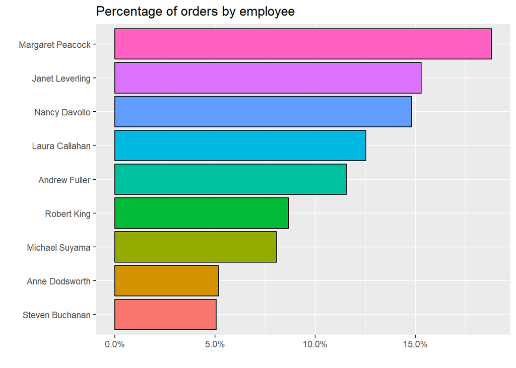

```r
zdruzena_nova %>%
  count(EmployeeName) %>%
  mutate(Procent = n / sum(n)) %>%
  ungroup() %>%
  mutate(EmployeeName = fct_reorder(EmployeeName, Procent)) %>%
  ggplot(aes(Procent, EmployeeName, fill = EmployeeName)) +
  geom_col(color = "black") +
  scale_x_continuous(labels = percent_format()) +
  theme(legend.position = "none") +
  labs(x="", y="", title = "Percentage of orders by employee")
```